# qPCR re-extraction inhibition results

## Making 3D figure

```r
# library(plotly)
```

[output not shown]

```r
#
```

[output not shown]

```r
# p3d <-plot_ly(data = df_for_3d, x = ~x_dist, y = ~y_dist, z = ~depth, type = "scatter3d", mode = "markers", size = ~log_quant, color = ~tide, colors = c("dodgerblue", "darkmagenta"))
```

[output not shown]

```r
#
```

[output not shown]

```r
# p3d %>%
```

[output not shown]

```r
#   layout(scene = list(xaxis = list(title = 'Perpendicular transect'),
```

[output not shown]

```r
#                      yaxis = list(title = 'Parallel transect'),
```

[output not shown]

```r
#                      zaxis = list(title = 'Depth')))
```

[output not shown]

The 3D plot is actually pretty hard to interpret. Let’s pivot to displaying the depth for the parallel and perpendicular transects in two plots.

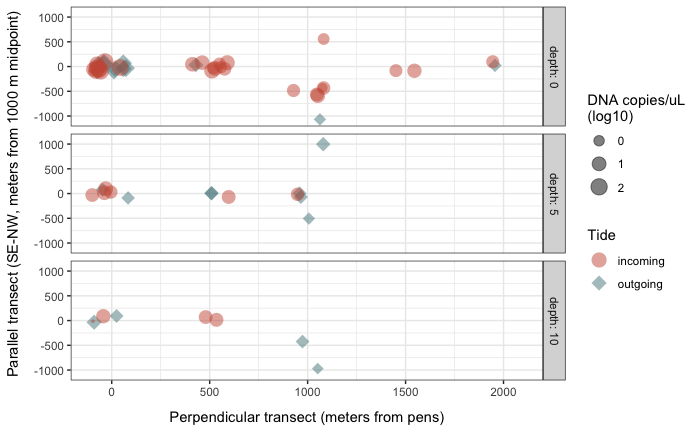

```r
# I want to explicitly plot NAs on here to show where we sampled but didn't have data

df_for_3d %>%
  mutate(depth = -1*depth) %>%
  filter(!is.na(depth)) %>%
  ggplot(aes(x = x_dist, y = y_dist, size = log_quant, color = tide, shape = tide)) +
  geom_jitter(alpha = 0.5, width = 100, height = 100) +
  theme_bw() +
  facet_grid(rows = vars(depth), labeller = label_both) +
  labs(x = "Perpendicular transect (meters from pens)",
       y = "Parallel transect (SE-NW, meters from 1000 m midpoint)",
       color = "Tide",
       shape = "Tide",
       size = "DNA copies/uL\n(log10)") +
  theme(
    axis.title.x = element_text(margin = margin(t = 10)),
    axis.title.y = element_text(margin = margin(r = 10))
  ) +
  scale_shape_manual(values = c(16, 18), na.value = 1) +
  scale_color_manual(values = mycols) +
  guides(color = guide_legend(override.aes = list(size = 5)))

ggsave("pdf_outputs/depth_transects2022.png", width = 6, height = 7)
```

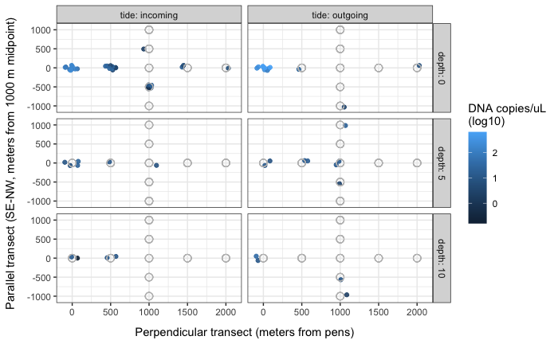

```r
# I want to explicitly plot NAs on here to show where we sampled but didn't have data
tmp <- df_for_3d %>%
  mutate(depth = -1*depth) %>%
  filter(!is.na(depth))


### try a simple version
tmp %>%
  ggplot() +
  geom_jitter(aes(x = x_dist, y = y_dist, color = log_quant), size = 1.5, alpha = 0.9, width = 100, height = 70) +
  geom_point(data = tmp[is.na(tmp$log_quant),], aes(x_dist, y_dist), color = "gray", shape = 1, size = 3) +
  theme_bw() +
  facet_grid(rows = vars(depth), cols = vars(tide), labeller = label_both) +
  scale_color_gradient(na.value = NA) +
  #scale_shape_manual(na.value = 2) +
  labs(x = "Perpendicular transect (meters from pens)",
       y = "Parallel transect (SE-NW, meters from 1000 m midpoint)",
       color = "DNA copies/uL\n(log10)") +
   theme(
    axis.title.x = element_text(margin = margin(t = 10)),
    axis.title.y = element_text(margin = margin(r = 10))
  )

ggsave("pdf_outputs/depth_transects2022_v2.png", width = 6, height = 4)
```

Relationship between qPCR detections and depth

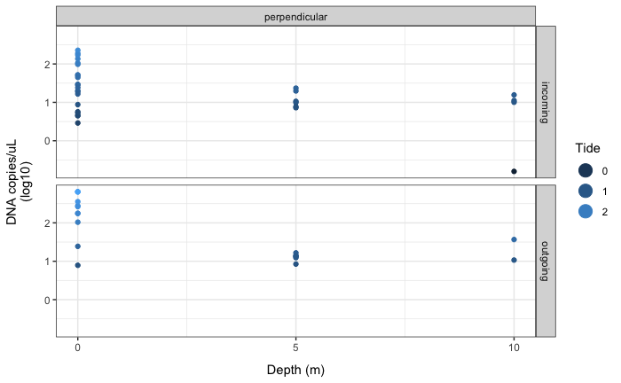

```r
df_for_3d %>%
  mutate(depth = -1*depth) %>%
  filter(!is.na(depth) &
           transect == "perpendicular") %>%
  ggplot(aes(x = depth, y = log_quant, color = log_quant)) +
  geom_point() +
  facet_grid(rows = vars(tide), cols = vars(transect)) +
  scale_x_continuous(breaks = c(0, 5, 10)) +
  theme_bw() +
  theme(
    axis.title.x = element_text(margin = margin(t = 10)),
    axis.title.y = element_text(margin = margin(r = 10))
  ) +
    scale_color_gradient(na.value = "gray") +
  guides(color = guide_legend(override.aes = list(size = 5))) +
   labs(x = "Depth (m)",
       y = "DNA copies/uL\n(log10)",
       color = "Tide",
       shape = "Tide",
       size = "DNA copies/uL\n(log10)")
```

Is it worth fitting a linear model to this?

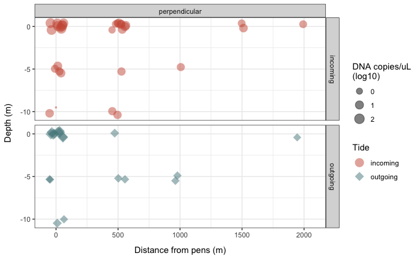

```r
df_for_3d %>%
  #mutate(depth = -1*depth) %>%
  filter(!is.na(depth) &
           transect == "perpendicular") %>%
  ggplot(aes(x = x_dist, y = depth, size = log_quant, color = tide, shape = tide)) +
  geom_jitter(alpha = 0.5, width = 70, height = 0.5) +
  facet_grid(rows = vars(tide), cols = vars(transect)) +
  #geom_smooth(method = "lm", se = F) +
  theme_bw() +
  theme(
    axis.title.x = element_text(margin = margin(t = 10)),
    axis.title.y = element_text(margin = margin(r = 10))
  ) +
  scale_shape_manual(values = c(16, 18)) +
  scale_color_manual(values = mycols) +
  scale_y_continuous(breaks = c(0, -5, -10)) +
   guides(color = guide_legend(override.aes = list(size = 5))) +
   labs(y = "Depth (m)",
       x = "Distance from pens (m)",
       color = "Tide",
       shape = "Tide",
       size = "DNA copies/uL\n(log10)")

ggsave("pdf_outputs/depth_by_distance.png", width = 6, height = 5)
```

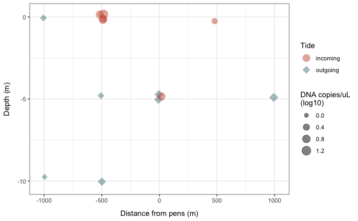

```r
df_for_3d %>%
  #mutate(depth = -1*depth) %>%
  mutate(transect = ifelse(distance_from_pens == 1000 & transect == "perpendicular", "parallel", transect)) %>%
  mutate(y_dist = ifelse(distance_from_pens == 1000 & transect == "parallel", 0, y_dist)) %>%
  filter(!is.na(depth) &
           str_detect(transect, "parallel")) %>%
  ggplot(aes(x = y_dist, y = depth, size = log_quant, color = tide, shape = tide)) +
  geom_jitter(alpha = 0.5, width = 25, height = 0.3) +
  #facet_grid(rows = vars(tide), cols = vars(transect)) +
  #geom_smooth(method = "lm", se = F) +
  theme_bw() +
  theme(
    axis.title.x = element_text(margin = margin(t = 10)),
    axis.title.y = element_text(margin = margin(r = 10))
  ) +
  scale_shape_manual(values = c(16, 18)) +
  scale_color_manual(values = mycols) +
  scale_y_continuous(breaks = c(0, -5, -10)) +
   guides(color = guide_legend(override.aes = list(size = 5))) +
   labs(y = "Depth (m)",
       x = "Distance from pens (m)",
       color = "Tide",
       shape = "Tide",
       size = "DNA copies/uL\n(log10)")

ggsave("pdf_outputs/depth_by_distance_parallel.png", width = 6, height = 5)
```

```r
NA
NA
```

% of detections in surface samples vs. at depth?

```r
merged_df_both_years %>%
  filter(!is.na(quant_per_ul) & quant_per_ul > 5 & year == "2022") %>%
  group_by(depth) %>%
  tally()
```

| depth | n |
| --- | --- |
| 0 | 33 |
| 5 | 13 |
| 10 | 6 |

```r
NA
```

```r
6/52
```

```
[1] 0.1153846
```

### Depth Stats - ANOVAs

1. Test whether there is statistically more DNA at the surface compared to the 5m and 10m depths
2. and then test whether incoming/outgoing tide makes a difference

```r
for_anova <- merged_df_both_years %>%
```

[output not shown]

```r
  filter(year == 2022 &
```

[output not shown]

```r
           !is.na(depth) &
```

[output not shown]

```r
           !is.na(quant_per_ul) &
```

[output not shown]

```r
           distance_from_pens == 0) %>%
```

[output not shown]

```r
  group_by(depth, tide)
```

[output not shown]

```r
for_anova %>%
  summarise(sd = sd(log_dna_ul))
```

| depth | tide | sd |
| --- | --- | --- |
| 0 | incoming | 0.3016063 |
| 0 | outgoing | 0.2866174 |
| 5 | incoming | 0.2421083 |
| 5 | outgoing | 0.1184928 |
| 10 | incoming | 1.4087290 |
| 10 | outgoing | 0.3779782 |

```r
NA
```

171 samples per depth from 2022, but the number of detections per depth is much smaller.

multiple comparisons: every depth x tide compared to every other depth x tide

[output not shown]

```r
# significance of depth (without tide)
TukeyHSD(model.dt, conf.level = 0.95)
```

```
  Tukey multiple comparisons of means
    95% family-wise confidence level

Fit: aov(formula = for_anova$log_dna_ul ~ for_anova$depth, data = for_anova)

$`for_anova$depth`
           diff       lwr        upr     p adj
5-0  -1.1457781 -1.722885 -0.5686716 0.0001234
10-0 -1.4885476 -2.165265 -0.8118302 0.0000314
10-5 -0.3427694 -1.133005  0.4474662 0.5347180
```

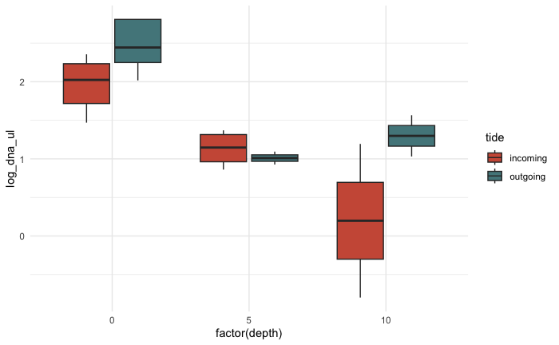

```r
tukey
```

[output not shown]

All depth data:

```r
alldepth <- merged_df_both_years %>%
  filter(year == 2022 &
           !is.na(depth) &
           !is.na(quant_per_ul)) %>%
  group_by(depth, tide)

depth.tide.all <- aov(alldepth$quant_per_ul ~ alldepth$tide / factor(alldepth$depth))

summary(depth.tide.all)
```

[output not shown]

Testing for differences at the surface across “stations”

| sample | CT | quant_per_ul | label | tide | distance_from_pens | time_of_day | depth | transect | sample_date | year | station |
| --- | --- | --- | --- | --- | --- | --- | --- | --- | --- | --- | --- |
| e01260 | 35.946815 | 24.4805574 | 500m_surface_AM | outgoing | 500 | AM | 0 | perpendicular | 2022_05_05 | 2022 | A |
| e01344 | 37.714287 | 3.4198627 | B3_1000m_surface_AM | outgoing | 1000 | AM | 0 | parallel_B3 | 2022_05_05 | 2022 | F |
| e01345 | 37.320244 | 4.4730803 | 500m_surface_PM | incoming | 500 | PM | 0 | perpendicular | 2022_05_05 | 2022 | A |
| e01345 | 33.94346 | 44.6481419 | 500m_surface_PM | incoming | 500 | PM | 0 | perpendicular | 2022_05_05 | 2022 | A |
| e01345 | 36.33605 | 8.7464523 | 500m_surface_PM | incoming | 500 | PM | 0 | perpendicular | 2022_05_05 | 2022 | A |
| e01346 | 37.955975 | 2.9006335 | 500m_surface_PM | incoming | 500 | PM | 0 | perpendicular | 2022_05_05 | 2022 | A |
| e01346 | 35.20012 | 18.9651096 | 500m_surface_PM | incoming | 500 | PM | 0 | perpendicular | 2022_05_05 | 2022 | A |
| e01346 | 35.11276 | 20.1282239 | 500m_surface_PM | incoming | 500 | PM | 0 | perpendicular | 2022_05_05 | 2022 | A |
| e01347 | 34.60256 | 28.4953952 | 500m_surface_PM | incoming | 500 | PM | 0 | perpendicular | 2022_05_05 | 2022 | A |
| e01347 | 37.276955 | 4.6069768 | 500m_surface_PM | incoming | 500 | PM | 0 | perpendicular | 2022_05_05 | 2022 | A |

[output cut: 7 more lines]

only two observations on outgoing tide.

| sample | CT | quant_per_ul | label | tide | distance_from_pens | time_of_day | depth | transect | sample_date | year | station |
| --- | --- | --- | --- | --- | --- | --- | --- | --- | --- | --- | --- |
| e01345 | 37.320244 | 4.4730803 | 500m_surface_PM | incoming | 500 | PM | 0 | perpendicular | 2022_05_05 | 2022 | A |
| e01345 | 33.94346 | 44.6481419 | 500m_surface_PM | incoming | 500 | PM | 0 | perpendicular | 2022_05_05 | 2022 | A |
| e01345 | 36.33605 | 8.7464523 | 500m_surface_PM | incoming | 500 | PM | 0 | perpendicular | 2022_05_05 | 2022 | A |
| e01346 | 37.955975 | 2.9006335 | 500m_surface_PM | incoming | 500 | PM | 0 | perpendicular | 2022_05_05 | 2022 | A |
| e01346 | 35.20012 | 18.9651096 | 500m_surface_PM | incoming | 500 | PM | 0 | perpendicular | 2022_05_05 | 2022 | A |
| e01346 | 35.11276 | 20.1282239 | 500m_surface_PM | incoming | 500 | PM | 0 | perpendicular | 2022_05_05 | 2022 | A |
| e01347 | 34.60256 | 28.4953952 | 500m_surface_PM | incoming | 500 | PM | 0 | perpendicular | 2022_05_05 | 2022 | A |
| e01347 | 37.276955 | 4.6069768 | 500m_surface_PM | incoming | 500 | PM | 0 | perpendicular | 2022_05_05 | 2022 | A |
| e01347 | 34.837845 | 24.2746472 | 500m_surface_PM | incoming | 500 | PM | 0 | perpendicular | 2022_05_05 | 2022 | A |
| e01357 | 38.328342 | 2.2506529 | T2_500m_surface_PM | incoming | 500 | PM | 0 | parallel_T2 | 2022_05_05 | 2022 | C |

[output cut: 5 more lines]

### Working on LOD

The actual code for the calcs is in another Rmd.

| Well | Fluor | Sample | Cq | SQ | Target |
| --- | --- | --- | --- | --- | --- |
| A1 | FAM | 1000000 | 16.91713 | 1e+06 | Oke_COI |
| A2 | FAM | 1000000 | 16.63301 | 1e+06 | Oke_COI |
| B1 | FAM | 100000 | 21.00850 | 1e+05 | Oke_COI |
| B2 | FAM | 100000 | 20.67041 | 1e+05 | Oke_COI |
| B3 | FAM | 100000 | 20.80954 | 1e+05 | Oke_COI |
| C1 | FAM | 10000 | 24.22830 | 1e+04 | Oke_COI |
| C2 | FAM | 10000 | 23.99878 | 1e+04 | Oke_COI |
| C3 | FAM | 10000 | 24.13067 | 1e+04 | Oke_COI |
| D1 | FAM | 1000 | 28.17053 | 1e+03 | Oke_COI |
| D2 | FAM | 1000 | 27.55826 | 1e+03 | Oke_COI |

[output cut: 140 more lines]